# Image Smoothing

```python
#-*- coding:utf-8 -*-
import cv2
import numpy as np

def nothing(x):
    pass

img = cv2.imread('lena.png')

cv2.namedWindow('image')
cv2.createTrackbar('K','image',1,20, nothing) #생성된 윈도우 창에 트랙바를 부착 #ウィンドウにトラックバー(trackbar)を作る

while(1):
    if cv2.waitKey(1) & 0xFF == 27:
        break
    k = cv2.getTrackbarPos('K','image')

    #(0,0)이면 에러가 발생함으로 1로 치환 (0,0)ならエラーが発生することで1で置き換え
    if k == 0:
        k = 1

    # trackbar에 의해서 (1,1) ~ (20,20) kernel생성 trackbarによって(1,1)~(20,20)kernel生成
    kernel = np.ones((k,k),np.float32)/(k*2)
    dst = cv2.filter2D(img,-1,kernel)

    cv2.imshow('image',dst)

cv2.destroyAllWindows()
```

### Averaging

Box형태의 kernel을 이미지에 적용한 후 평균값을 box의 중심점에 적용하는 형태입니다.  
Box形式のkernelを画像に適用し、平均値をboxの中心点に適用する形態です。

cv2.blur(src, ksize) → dst  
src – Chennel수는 상관없으나, depth(Data Type)은 CV_8U, CV_16U, CV_16S, CV_32F or CV_64F.  
ksize – kernel のsize (ex; (3,3))

depth(Data Type)

- CV_8U : 8-bit unsigned integer: uchar ( 0..255 )
- CV_8S : 8-bit signed integer: schar ( -128..127 )
- CV_16U : 16-bit unsigned integer: ushort ( 0..65535 )
- CV_16S : 16-bit signed integer: short ( -32768..32767 )
- CV_32S : 32-bit signed integer: int ( -2147483648..2147483647 )
- CV_32F : 32-bit floating-point number: float ( -FLT_MAX..FLT_MAX, INF, NAN )
- CV_64F : 64-bit floating-point number: double ( -DBL_MAX..DBL_MAX, INF, NAN )

[figure not shown]

```python
import cv2
import numpy as np
from matplotlib import pyplot as plt

img = cv2.imread('opencv_logo.jpg')

blur = cv2.blur(img,(5,5))

plt.subplot(121),plt.imshow(img),plt.title('Original')
plt.xticks([]), plt.yticks([])
plt.subplot(122),plt.imshow(blur),plt.title('Blurred')
plt.xticks([]), plt.yticks([])
plt.show()
```

### Gaussian Filtering

box filter는 동일한 값으로 구성된 kernel을 사용하지만, Gaussian Filter는 Gaussian함수를 이용한 Kernel을 적용합니다.  
즉, kernel 행렬의 값을 Gaussian 함수를 통해서 수학적으로 생성하여 적용합니다.  
kernel의 사이즈는 양수이면서 홀수로 지정을 해야 합니다.  
이미지의 Gaussian Noise (전체적으로 밀도가 동일한 노이즈, 백색노이즈)를 제거하는 데 가장 효과적입니다.

画像のGaussian Noise（全体的に密度が同じノイズ、白色ノイズ）を除去するのに最も効果的です。

cv2.GaussianBlur(img, ksize, sigmaX)  
img – Chennel수는 상관없으나, depth(Data Type)은 CV_8U, CV_16U, CV_16S, CV_32F or CV_64F.  
Chennel数はかまいません  
ksize – (width, height)のkernel size. width와 height両数の奇数で指定しなければならない  
sigmaX – Gaussian kernel standard deviation in X direction.

[figure not shown]

```python
import cv2
import numpy as np
from matplotlib import pyplot as plt

img = cv2.imread('opencv_logo.jpg')

blur = cv2.GaussianBlur(img,(5,5),0)

plt.subplot(121),plt.imshow(img),plt.title('Original')
plt.xticks([]), plt.yticks([])
plt.subplot(122),plt.imshow(blur),plt.title('Blurred')
plt.xticks([]), plt.yticks([])
plt.show()
```

### Median Filtering

kernel window와 pixel의 값들을 정렬한 후에 중간값을 선택하여 적용합니다. salt-and-pepper noise 제거에 가장 효과적입니다.  
예를 들면 아래와 같이 kernel window을 적용시킨 결과가 다음과 같다면

kernel windowとpixelの値をソートした後に中間値を選択適用します。 salt-and-pepper noiseの除去に最も効果的です。

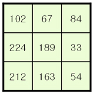

크기순으로 정렬을 하면 33,54,67,84,102,163,189,212,224입니다. 이중에 중간값인 102가 중앙값으로 결정이 됩니다.  
(중앙에 있는 189가 102로 변경됨.)

サイズの順に並べると、33,54,67,84,102,163,189,212,224となります。 この中で、中間値である102が中央値に決まります。  
(中央の189が102に変更)

cv2.medianBlur(src, ksize)  
src – 1,3,4 channel image. depth가 CV_8U, CV_16U, or CV_32F なら ksize는 3または5, CV_8Uならもっと大きいksizeできる  
ksize – 1보다 큰 홀수 一より大きい奇数

[figure not shown]

```python
import cv2
import numpy as np
from matplotlib import pyplot as plt

img = cv2.imread('opencv_logo2.jpg')

median = cv2.medianBlur(img,5)

plt.subplot(121),plt.imshow(img),plt.title('Original')
plt.xticks([]), plt.yticks([])
plt.subplot(122),plt.imshow(median),plt.title('Blurred')
plt.xticks([]), plt.yticks([])
plt.show()
```

### Bilateral Filtering

지금까지의 Blur처리는 경계선까지 Blur처리가 되어, 경계선이 흐려지게 됩니다.  
Bilateral Filtering(양방향 필터)은 경계선을 유지하면서 Gaussian Blur처리를 해주는 방법입니다.  
Gaussian 필터를 적용하고, 또 하나의 Gaussian 필터를 주변 pixel까지 고려하여 적용하는 방식입니다.  
これまでのBlur処理は境界線までBlur処理され、境界線がぼやけます。  
Bilateral Filtering(双方向フィルター)は境界線を維持しながらガウスシアン Blur処理を行う方法です。  
Gaussianフィルターを適用し、また一つのGaussianフィルターを周辺のpixelまで考慮して適用する方式です。

cv2.bilateralFilter(src, d, sigmaColor, sigmaSpace)

src – 8-bit, 1 or 3 Channel image  
d – filteringする時 考慮すべき周辺 pixel 径  
sigmaColor – Colorを考慮する空間。. 数字が大きければ遠くの色も考慮する。  
sigmaSpace – 数字が大きければ遠くの色も考慮する。

[figure not shown]

```python
import cv2
import numpy as np
from matplotlib import pyplot as plt

img = cv2.imread('opencv_logo3.jpg')

blur = cv2.bilateralFilter(img,9,75,75)

plt.subplot(121),plt.imshow(img),plt.title('Original')
plt.xticks([]), plt.yticks([])
plt.subplot(122),plt.imshow(blur),plt.title('Blurred')
plt.xticks([]), plt.yticks([])
plt.show()
```